# Chapter 4. Clustering and classification.

Today is:

```
## [1] "Thu Nov 19 22:57:58 2020"
```

#### Task 1. Create chapter4.Rmd => Done!

#### Task 2. Load Boston data.

Way to read data same as in DataCamp.

```r
library(MASS)
data("Boston")
```

Boston data is public data from MASS package including various data sets. Data was originally presented in 1978. The Boston Housing Dataset consists of price of houses in various places in Boston. Alongside with price, the dataset also provide information such as Crime (CRIM), areas of non-retail business in the town (INDUS), the age of people who own the house (AGE). Detailed information and links to original publications are presented [here](https://stat.ethz.ch/R-manual/R-devel/library/MASS/html/Boston.html).

Let’s check structure and dimensions.

```r
dim(Boston)
```

```
## [1] 506  14
```

```r
str(Boston)
```

```
## 'data.frame':    506 obs. of  14 variables:
##  $ crim   : num  0.00632 0.02731 0.02729 0.03237 0.06905 ...
##  $ zn     : num  18 0 0 0 0 0 12.5 12.5 12.5 12.5 ...
##  $ indus  : num  2.31 7.07 7.07 2.18 2.18 2.18 7.87 7.87 7.87 7.87 ...
##  $ chas   : int  0 0 0 0 0 0 0 0 0 0 ...
##  $ nox    : num  0.538 0.469 0.469 0.458 0.458 0.458 0.524 0.524 0.524 0.524 ...
##  $ rm     : num  6.58 6.42 7.18 7 7.15 ...
##  $ age    : num  65.2 78.9 61.1 45.8 54.2 58.7 66.6 96.1 100 85.9 ...
##  $ dis    : num  4.09 4.97 4.97 6.06 6.06 ...
##  $ rad    : int  1 2 2 3 3 3 5 5 5 5 ...
##  $ tax    : num  296 242 242 222 222 222 311 311 311 311 ...
##  $ ptratio: num  15.3 17.8 17.8 18.7 18.7 18.7 15.2 15.2 15.2 15.2 ...
##  $ black  : num  397 397 393 395 397 ...
##  $ lstat  : num  4.98 9.14 4.03 2.94 5.33 ...
##  $ medv   : num  24 21.6 34.7 33.4 36.2 28.7 22.9 27.1 16.5 18.9 ...
```

So, data has 506 observations and 14 variables. Most of the variables are numerical, except dummy variable chas and rad variable - index of accessibility to radial highways.

#### Task 3. Graphical overvie of the data.

Let’s do graphical overview of the data. I tryed ggpairs but too much data. Than let’s use example from DataCamp. Correlation using cycles.

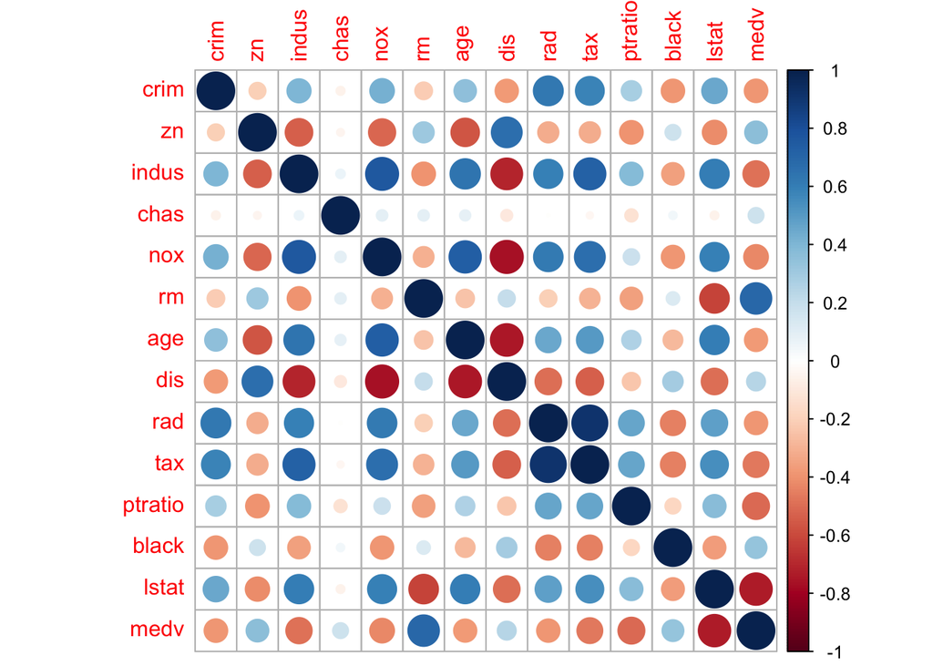

```r
cor_matrix<-cor(Boston)
corrplot(cor_matrix, method="circle")
```

Now, let’s print out summary.

```r
summary(Boston)
```

```
##       crim                zn             indus            chas
##  Min.   : 0.00632   Min.   :  0.00   Min.   : 0.46   Min.   :0.00000
##  1st Qu.: 0.08205   1st Qu.:  0.00   1st Qu.: 5.19   1st Qu.:0.00000
##  Median : 0.25651   Median :  0.00   Median : 9.69   Median :0.00000
##  Mean   : 3.61352   Mean   : 11.36   Mean   :11.14   Mean   :0.06917
##  3rd Qu.: 3.67708   3rd Qu.: 12.50   3rd Qu.:18.10   3rd Qu.:0.00000
##  Max.   :88.97620   Max.   :100.00   Max.   :27.74   Max.   :1.00000
##       nox               rm             age              dis
##  Min.   :0.3850   Min.   :3.561   Min.   :  2.90   Min.   : 1.130
##  1st Qu.:0.4490   1st Qu.:5.886   1st Qu.: 45.02   1st Qu.: 2.100
##  Median :0.5380   Median :6.208   Median : 77.50   Median : 3.207
##  Mean   :0.5547   Mean   :6.285   Mean   : 68.57   Mean   : 3.795
##  3rd Qu.:0.6240   3rd Qu.:6.623   3rd Qu.: 94.08   3rd Qu.: 5.188
##  Max.   :0.8710   Max.   :8.780   Max.   :100.00   Max.   :12.127
##       rad              tax           ptratio          black
##  Min.   : 1.000   Min.   :187.0   Min.   :12.60   Min.   :  0.32
##  1st Qu.: 4.000   1st Qu.:279.0   1st Qu.:17.40   1st Qu.:375.38
##  Median : 5.000   Median :330.0   Median :19.05   Median :391.44
##  Mean   : 9.549   Mean   :408.2   Mean   :18.46   Mean   :356.67
##  3rd Qu.:24.000   3rd Qu.:666.0   3rd Qu.:20.20   3rd Qu.:396.23
##  Max.   :24.000   Max.   :711.0   Max.   :22.00   Max.   :396.90
##      lstat            medv
##  Min.   : 1.73   Min.   : 5.00
##  1st Qu.: 6.95   1st Qu.:17.02
##  Median :11.36   Median :21.20
##  Mean   :12.65   Mean   :22.53
##  3rd Qu.:16.95   3rd Qu.:25.00
##  Max.   :37.97   Max.   :50.00
```

```r
bo_sc<-scale(Boston)
bo_sc<-as.data.frame(bo_sc)
summary(bo_sc)
```

```
##       crim                 zn               indus              chas
##  Min.   :-0.419367   Min.   :-0.48724   Min.   :-1.5563   Min.   :-0.2723
##  1st Qu.:-0.410563   1st Qu.:-0.48724   1st Qu.:-0.8668   1st Qu.:-0.2723
##  Median :-0.390280   Median :-0.48724   Median :-0.2109   Median :-0.2723
##  Mean   : 0.000000   Mean   : 0.00000   Mean   : 0.0000   Mean   : 0.0000
##  3rd Qu.: 0.007389   3rd Qu.: 0.04872   3rd Qu.: 1.0150   3rd Qu.:-0.2723
##  Max.   : 9.924110   Max.   : 3.80047   Max.   : 2.4202   Max.   : 3.6648
##       nox                rm               age               dis
##  Min.   :-1.4644   Min.   :-3.8764   Min.   :-2.3331   Min.   :-1.2658
##  1st Qu.:-0.9121   1st Qu.:-0.5681   1st Qu.:-0.8366   1st Qu.:-0.8049
##  Median :-0.1441   Median :-0.1084   Median : 0.3171   Median :-0.2790
##  Mean   : 0.0000   Mean   : 0.0000   Mean   : 0.0000   Mean   : 0.0000
##  3rd Qu.: 0.5981   3rd Qu.: 0.4823   3rd Qu.: 0.9059   3rd Qu.: 0.6617
##  Max.   : 2.7296   Max.   : 3.5515   Max.   : 1.1164   Max.   : 3.9566
##       rad               tax             ptratio            black
##  Min.   :-0.9819   Min.   :-1.3127   Min.   :-2.7047   Min.   :-3.9033
##  1st Qu.:-0.6373   1st Qu.:-0.7668   1st Qu.:-0.4876   1st Qu.: 0.2049
##  Median :-0.5225   Median :-0.4642   Median : 0.2746   Median : 0.3808
##  Mean   : 0.0000   Mean   : 0.0000   Mean   : 0.0000   Mean   : 0.0000
##  3rd Qu.: 1.6596   3rd Qu.: 1.5294   3rd Qu.: 0.8058   3rd Qu.: 0.4332
##  Max.   : 1.6596   Max.   : 1.7964   Max.   : 1.6372   Max.   : 0.4406
##      lstat              medv
##  Min.   :-1.5296   Min.   :-1.9063
##  1st Qu.:-0.7986   1st Qu.:-0.5989
##  Median :-0.1811   Median :-0.1449
##  Mean   : 0.0000   Mean   : 0.0000
##  3rd Qu.: 0.6024   3rd Qu.: 0.2683
##  Max.   : 3.5453   Max.   : 2.9865
```

Ok. Now they are looking with same range. Continue with the task. Create variable crime. You know…

```r
bins <- quantile(bo_sc$crim)
crime <- cut(bo_sc$crim, breaks = bins, include.lowest = TRUE)
bo_sc <- dplyr::select(bo_sc, -crim)
bo_sc <- data.frame(bo_sc, crime)
```

Print out head.

```r
head(bo_sc)
```

```
##           zn      indus       chas        nox        rm        age      dis
## 1  0.2845483 -1.2866362 -0.2723291 -0.1440749 0.4132629 -0.1198948 0.140075
## 2 -0.4872402 -0.5927944 -0.2723291 -0.7395304 0.1940824  0.3668034 0.556609
## 3 -0.4872402 -0.5927944 -0.2723291 -0.7395304 1.2814456 -0.2655490 0.556609
## 4 -0.4872402 -1.3055857 -0.2723291 -0.8344581 1.0152978 -0.8090878 1.076671
## 5 -0.4872402 -1.3055857 -0.2723291 -0.8344581 1.2273620 -0.5106743 1.076671
## 6 -0.4872402 -1.3055857 -0.2723291 -0.8344581 0.2068916 -0.3508100 1.076671
##          rad        tax    ptratio     black      lstat       medv
## 1 -0.9818712 -0.6659492 -1.4575580 0.4406159 -1.0744990  0.1595278
## 2 -0.8670245 -0.9863534 -0.3027945 0.4406159 -0.4919525 -0.1014239
## 3 -0.8670245 -0.9863534 -0.3027945 0.3960351 -1.2075324  1.3229375
## 4 -0.7521778 -1.1050216  0.1129203 0.4157514 -1.3601708  1.1815886
## 5 -0.7521778 -1.1050216  0.1129203 0.4406159 -1.0254866  1.4860323
## 6 -0.7521778 -1.1050216  0.1129203 0.4101651 -1.0422909  0.6705582
##             crime
## 1 [-0.419,-0.411]
## 2 [-0.419,-0.411]
## 3 [-0.419,-0.411]
## 4 [-0.419,-0.411]
## 5 [-0.419,-0.411]
## 6 [-0.419,-0.411]
```

Look’s good.

Now creating test and training set. And will print heads.

```r
n_rows<-length(bo_sc$zn)
ind<-sample(n_rows, size=n_rows*0.8)
train=bo_sc[ind,]
test=bo_sc[-ind,]
print("test")
```

```
## [1] "test"
```

```r
head(test)
```

```
##             zn      indus       chas        nox         rm        age
## 8   0.04872402 -0.4761823 -0.2723291 -0.2648919 -0.1603069  0.9778406
## 9   0.04872402 -0.4761823 -0.2723291 -0.2648919 -0.9302853  1.1163897
## 13  0.04872402 -0.4761823 -0.2723291 -0.2648919 -0.5630867 -1.0506607
## 15 -0.48724019 -0.4368257 -0.2723291 -0.1440749 -0.2684739  0.5657458
## 26 -0.48724019 -0.4368257 -0.2723291 -0.1440749 -0.9758293  0.6083763
## 38 -0.48724019 -0.7545936 -0.2723291 -0.4806367 -0.6185935 -0.9618471
##           dis        rad        tax   ptratio      black      lstat        medv
## 8  1.02362490 -0.5224844 -0.5769480 -1.503749  0.4406159  0.9097999  0.49659041
## 9  1.08612163 -0.5224844 -0.5769480 -1.503749  0.3281233  2.4193794 -0.65594629
## 13 0.78636527 -0.5224844 -0.5769480 -1.503749  0.3705134  0.4280788 -0.09055093
## 15 0.31668999 -0.6373311 -0.6006817  1.175303  0.2557205 -0.3351131 -0.47110550
## 26 0.31322322 -0.6373311 -0.6006817  1.175303 -0.5833190  0.5401069 -0.93864397
## 38 0.06608569 -0.5224844 -0.7668172  0.343873  0.4406159 -0.5437656 -0.16666184
##              crime
## 8   (-0.411,-0.39]
## 9   (-0.411,-0.39]
## 13  (-0.411,-0.39]
## 15 (-0.39,0.00739]
## 26 (-0.39,0.00739]
## 38 [-0.419,-0.411]
```

```r
print("train")
```

```
## [1] "train"
```

```r
head(train)
```

```
##             zn      indus       chas        nox         rm        age
## 466 -0.4872402  1.0149946 -0.2723291  0.8656106 -0.7481093 -0.7238268
## 200  3.5860878 -1.4090789 -0.2723291 -1.3090965  0.9825630 -1.8926130
## 236 -0.4872402 -0.7196100 -0.2723291 -0.4115983 -0.2827064 -0.2513388
## 497 -0.4872402 -0.2108898 -0.2723291  0.2615253 -1.2732886  0.1536509
## 489 -0.4872402  2.4201701 -0.2723291  0.4686402 -1.1822006  0.8570542
## 302  0.9705825 -0.7356442 -0.2723291 -1.0502028  0.4346117 -1.0009251
##             dis        rad        tax    ptratio      black      lstat
## 466 -0.34598432  1.6596029  1.5294129  0.8057784 -0.2439790  0.2068231
## 200  1.83233070 -0.7521778 -0.0370076 -0.6723188  0.4406159 -1.1333138
## 236 -0.06797834 -0.1779443 -0.6006817 -0.4875567  0.2199025 -0.2482913
## 497 -0.47320981 -0.4076377 -0.1022751  0.3438730  0.4406159  1.1884699
## 489 -0.93751873 -0.6373311  1.7964164  0.7595879  0.4207900  0.7571615
## 302  0.80574116 -0.2927910 -0.4701466 -1.0880337  0.4280193 -0.4415399
##            medv           crime
## 466 -0.28626471 (-0.39,0.00739]
## 200  1.34468345 [-0.419,-0.411]
## 236  0.15952779 (-0.39,0.00739]
## 497 -0.30801068 (-0.39,0.00739]
## 489 -0.79729513  (-0.411,-0.39]
## 302 -0.05793197 [-0.419,-0.411]
```

#### Task 5. LDA

Fitting model crime against all.

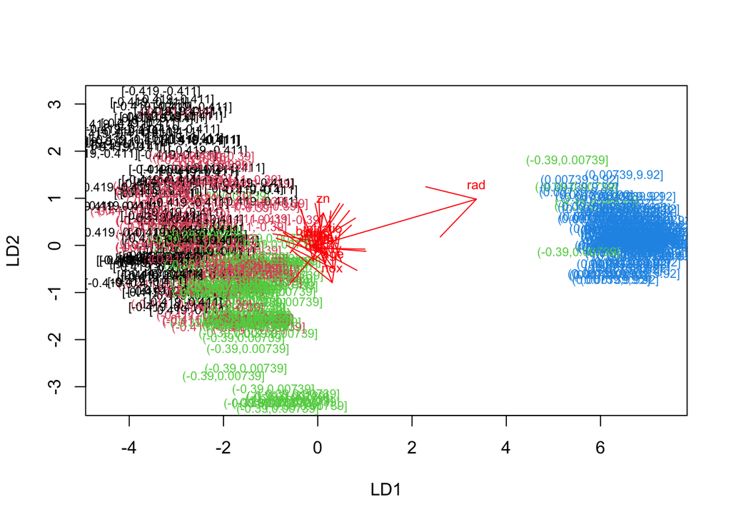

```r
lda.fit<-lda(crime~.,data=train)
lda.arrows <- function(x, myscale = 1, arrow_heads = 0.5, color = "red", tex = 0.75, choices = c(1,2)){
  heads <- coef(x)
  arrows(x0 = 0, y0 = 0,
         x1 = myscale * heads[,choices[1]],
         y1 = myscale * heads[,choices[2]], col=color, length = arrow_heads)
  text(myscale * heads[,choices], labels = row.names(heads),
       cex = tex, col=color, pos=3)
}
classes <- as.numeric(train$crime)

plot(lda.fit,dimen=2,col=classes,pch=classes)
lda.arrows(lda.fit, myscale = 1)
```

#### Task 6. Remove and predict.

I will take crime variable from test to correct_crime. And remove crime variable from test data.

```r
correct_crime <-test$crime
test <- dplyr::select(test, -crime)
head(test)
```

```
##             zn      indus       chas        nox         rm        age
## 8   0.04872402 -0.4761823 -0.2723291 -0.2648919 -0.1603069  0.9778406
## 9   0.04872402 -0.4761823 -0.2723291 -0.2648919 -0.9302853  1.1163897
## 13  0.04872402 -0.4761823 -0.2723291 -0.2648919 -0.5630867 -1.0506607
## 15 -0.48724019 -0.4368257 -0.2723291 -0.1440749 -0.2684739  0.5657458
## 26 -0.48724019 -0.4368257 -0.2723291 -0.1440749 -0.9758293  0.6083763
## 38 -0.48724019 -0.7545936 -0.2723291 -0.4806367 -0.6185935 -0.9618471
##           dis        rad        tax   ptratio      black      lstat        medv
## 8  1.02362490 -0.5224844 -0.5769480 -1.503749  0.4406159  0.9097999  0.49659041
## 9  1.08612163 -0.5224844 -0.5769480 -1.503749  0.3281233  2.4193794 -0.65594629
## 13 0.78636527 -0.5224844 -0.5769480 -1.503749  0.3705134  0.4280788 -0.09055093
## 15 0.31668999 -0.6373311 -0.6006817  1.175303  0.2557205 -0.3351131 -0.47110550
## 26 0.31322322 -0.6373311 -0.6006817  1.175303 -0.5833190  0.5401069 -0.93864397
## 38 0.06608569 -0.5224844 -0.7668172  0.343873  0.4406159 -0.5437656 -0.16666184
```

Looks OK. Now let’s predict and tabulate.

```r
lda.pred <- predict(lda.fit, newdata =test)
table(correct=correct_crime,predicted=lda.pred$class)
```

```
##                  predicted
## correct           [-0.419,-0.411] (-0.411,-0.39] (-0.39,0.00739] (0.00739,9.92]
##   [-0.419,-0.411]              18             10               1              0
##   (-0.411,-0.39]                3             16               7              0
##   (-0.39,0.00739]               2              8              15              1
##   (0.00739,9.92]                0              0               1             20
```

#### Task 7. Reload and etc.

Reload data and calculate euclidian and manhattan distances.

```r
data("Boston")
sc_data2<-scale(Boston)
dist_eu<-dist(sc_data2)
summary(dist_eu)
```

```
##    Min. 1st Qu.  Median    Mean 3rd Qu.    Max.
##  0.1343  3.4625  4.8241  4.9111  6.1863 14.3970
```

```r
dist_man <- dist(sc_data2, method = 'manhattan')
summary(dist_man)
```

```
##    Min. 1st Qu.  Median    Mean 3rd Qu.    Max.
##  0.2662  8.4832 12.6090 13.5488 17.7568 48.8618
```

**Clustering.**

2 clusters.

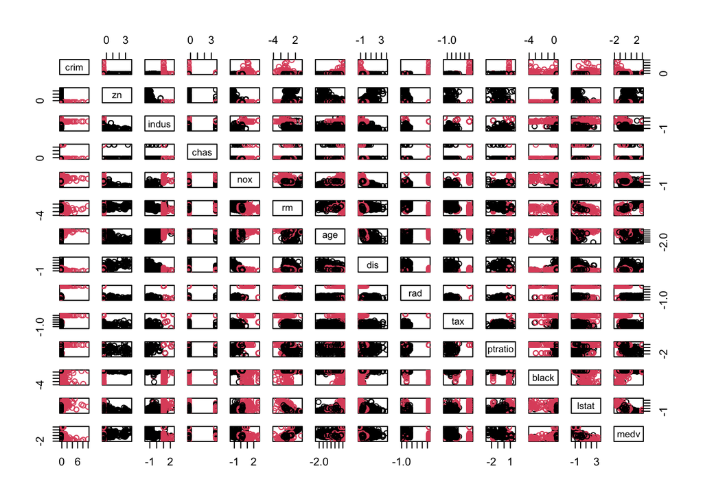

```r
km <-kmeans(sc_data2, centers = 2)
pairs(sc_data2, col = km$cluster)
```

3 clusters.

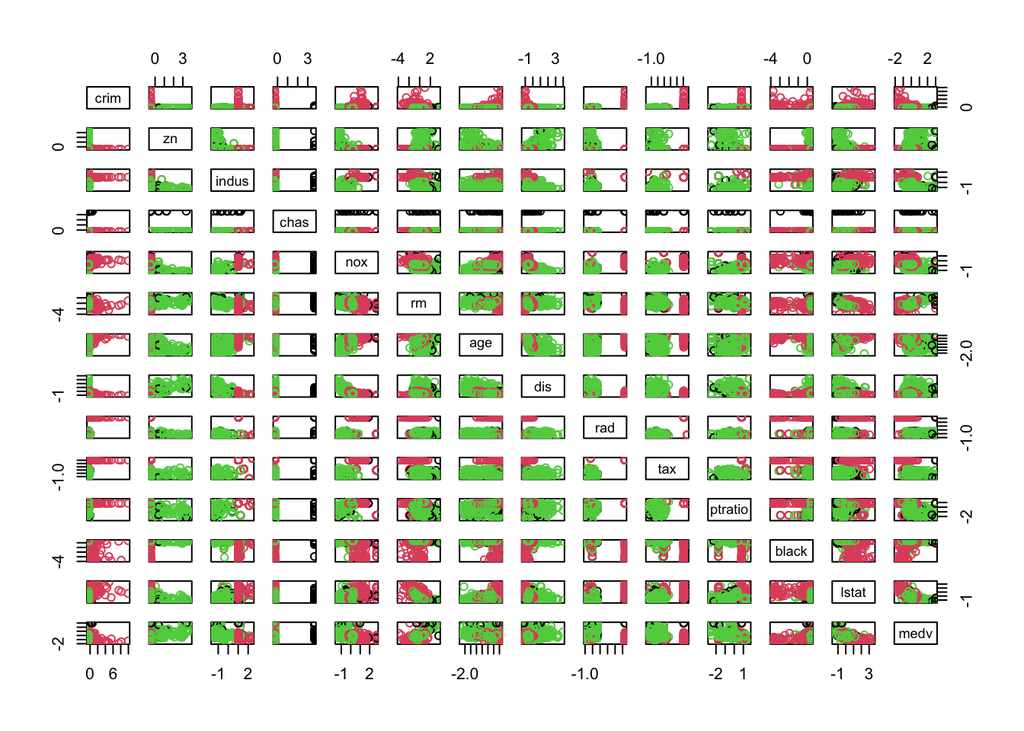

```r
km <-kmeans(sc_data2, centers = 3)
pairs(sc_data2, col = km$cluster)
```

4 clusters.

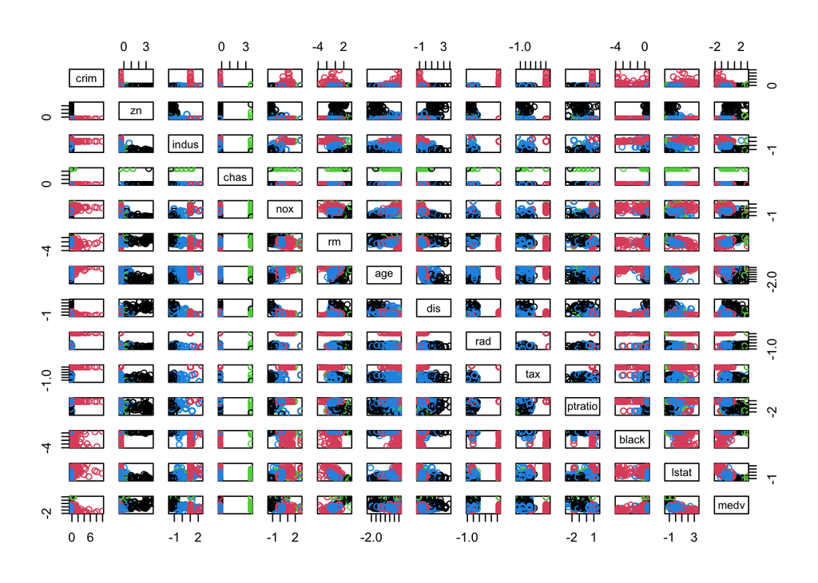

```r
km <-kmeans(sc_data2, centers = 4)
pairs(sc_data2, col = km$cluster)
```

Dear reviewer, if you could see and understand anything on this plots, you warmly welcome to give comments. I honestly could not see or understand presented pairs.

No Bonus.